# Assignment 7. Writing Functions

*Submission Instruction*. You will need to submit on **Blackboard**, in the **Assignment** section, a link to your assignment on your Github Webpage. Following [this](https://guides.github.com/features/pages/) to create a github webpage and posted a link to your assignment.

## Questions

```r
#input modules and dataframes
library(ggplot2)
library(tidyverse)
library(readxl)

titanic = read_csv('C:/Users/student/Documents/MATH421/data/titanic.csv')
titanic$Pclass = as.character(titanic$Pclass)
titanic$Survived = as.character(titanic$Survived)
```

1. Write a function: input a number x and return $x^2+3x+1$

```r
one<-function(x){
  x^2+3*x+1
}

one(2)
```

```
## [1] 11
```

2. Not using loops, write a function: input a vector and return the product of all the entries in the vector.

```r
two<-function(x){
  prod(x)
}
two(c(7,2,3))
```

```
## [1] 42
```

3. Using loops, write a function: input a vector and return the product of all the entries in the vector.

```r
three<-function(x){
  for (i in 1:length(x)) {
    product<-prod(x)
    return (product)
  }
}

three(c(7,2,3))
```

```
## [1] 42
```

**User defined functions combining with `apply` function.** The `apply` function returns a vector or array or list of values obtained by applying a function to margins of an array or matrix. For example, to calculate the column means of a matrix, one can use the `apply` function as follows.

```r
x = matrix(c(1:9), nrow=3)
x
```

```
##      [,1] [,2] [,3]
## [1,]    1    4    7
## [2,]    2    5    8
## [3,]    3    6    9
```

```r
apply(x, MARGIN=2, mean)
```

```
## [1] 2 5 8
```

```r
apply(x, MARGIN=1, sd)
```

```
## [1] 3 3 3
```

In the above examples, we use the `mean` function to apply to columns. There are some other similar bultin functions that works with `apply` such as `sum`, `median`, `sd` (for standard deviation). We can also use user-defined functions instead of these builtin functions. For examle, if one wants to take the sum of the `sine` columns wise, one can do as follows.

```r
f = function(w)
{
  return(sum(sin(w)))
}

apply(x, MARGIN = 2, f)
```

```
## [1]  1.891888 -1.995142  2.058463
```

In the above codes, function $f$ is applied to each columns of $x$. This codes can be shorten using **anonymous functions**, i.e. functions with nonames, as

```r
apply(x, 2, function(w){sum(sin(w))})
```

```
## [1]  1.891888 -1.995142  2.058463
```

In the above code, we write a function directly with the `apply` function this function does not need a name, also called **anonymous functions**.

4. Use the above approach to write to caculate or plot
- 1. the rows sum squares of matrix $x$ above.
- 2. the row sums of positive entries in $y$, where $y$ is a 100x100 matrix with the entries following standard normal distribution.
- 3. the row sums square of entries in $y$, where $y$ is a 100x100 matrix with the entries following standard normal distribution. What is the distribution of these sum squares?
- 4. the historgrams for each rows in $z$, where $z$ is a 3x1000 matrix with the entries following standard normal distribution.

```r
#a
apply(x,MARGIN=1,function(w){sum(w)^2})
```

```
## [1] 144 225 324
```

```r
#b
set.seed(2019)
y<-matrix(rnorm(10000),(nrows=100))
apply(y,MARGIN = 1, function(w){sum(w[w>=0])})
```

```
##   [1] 36.05571 26.70333 41.54731 41.44784 32.36128 39.47867 34.62030
##   [8] 31.75061 35.22453 30.67274 39.28759 38.29873 41.79624 46.21025
##  [15] 34.95514 43.32774 34.88522 31.42570 36.53357 37.55218 52.16677
##  [22] 37.82634 40.12880 47.08501 45.70306 37.79458 37.71721 41.62201
##  [29] 37.40497 36.34182 35.23926 30.37919 40.55415 32.33764 40.94604
##  [36] 52.47730 35.85933 34.61728 38.25868 27.69326 30.19464 43.98516
##  [43] 25.98451 40.41632 34.53501 39.12546 37.01780 41.23209 33.07671
##  [50] 45.84056 31.16780 38.78343 37.69670 30.01089 38.63438 36.65473
##  [57] 39.66107 35.94566 32.09792 28.11702 47.96815 43.35331 44.48076
##  [64] 46.77500 45.71619 29.55334 37.41524 47.10802 40.04349 45.89009
##  [71] 35.83775 37.93077 35.07279 35.69652 38.56861 30.03930 34.82983
##  [78] 39.95491 44.52243 31.19427 40.78546 33.58247 33.78501 44.45665
##  [85] 36.80874 46.46375 34.59366 42.15961 39.85349 41.45049 34.83929
##  [92] 37.66523 32.99994 43.52497 39.24921 49.90288 31.48066 42.85335
##  [99] 51.99754 35.91840
```

```r
#c
q<-apply(y,MARGIN=1,function(w){sum(w)^2})
q
```

```
##   [1]  24.84629088 104.27038355  97.26743823  32.11797213 301.52679882
##   [6]   0.03515235  47.50495969 123.70696790 160.84125529  82.42964298
##  [11]  24.53407536  33.97184383  34.07640917  92.52013795  41.49930606
##  [16]  51.95547540  23.83872988 345.96409698 129.26310415  57.09345269
##  [21] 278.66770302   1.41776589  11.50823013  43.29187148 112.70069778
##  [26]  75.78276663 163.47364586   0.08626093  44.01956709 135.95665835
##  [31] 447.12706380  71.70835299   5.98260565  40.03459631  15.95854133
##  [36] 416.74318175 153.34804280  53.30727168 352.84175762 256.44016423
##  [41] 616.11121297   0.39755264 327.56505145  17.54234705 338.32251699
##  [46]   6.02605594   4.98851497  38.86382582 105.15391889 182.74353645
##  [51] 291.59895420  22.71348691  91.40531934 320.11948536   2.01631357
##  [56]   0.37779270   3.97183814  13.56891938 109.70963294 191.78033537
##  [61]  40.25695522   1.99356804 118.13449175  64.24157677 244.57175233
##  [66] 271.02515246   0.01785171 149.76945099  10.49067029 211.45208817
##  [71]  25.60537873   0.09190504  62.76389109  11.78685600  62.74465723
##  [76] 332.50339301  68.61995092 105.62778842 186.50480725 166.62853643
##  [81]   0.15793894 165.93303327  12.09361571  82.21878725   0.48500114
##  [86] 176.38701897 225.03661161  32.94234811   0.36782370   8.66809341
##  [91] 130.68460446  48.83333136  54.89278639  28.01302400  20.12081993
##  [96] 189.32063231  19.73469024   0.04953053 634.05582194  66.26218550
```

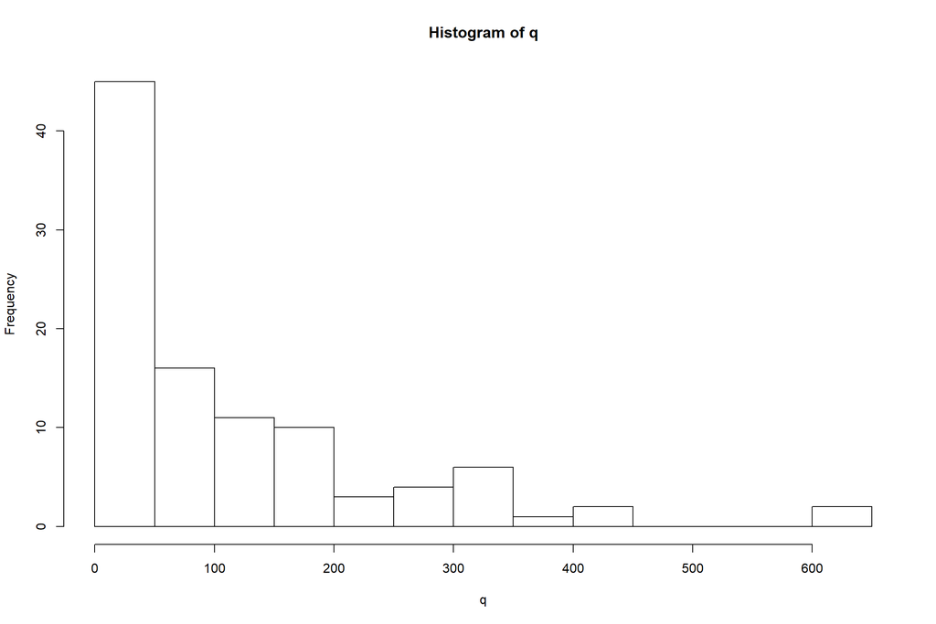

```r
hist(q,breaks=10)
```

```r
#The distribution is chi-square.
```

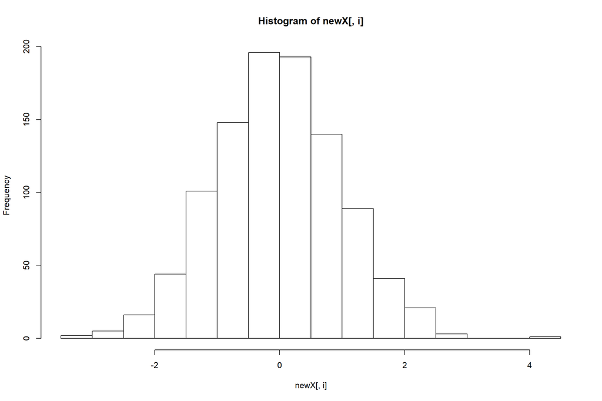

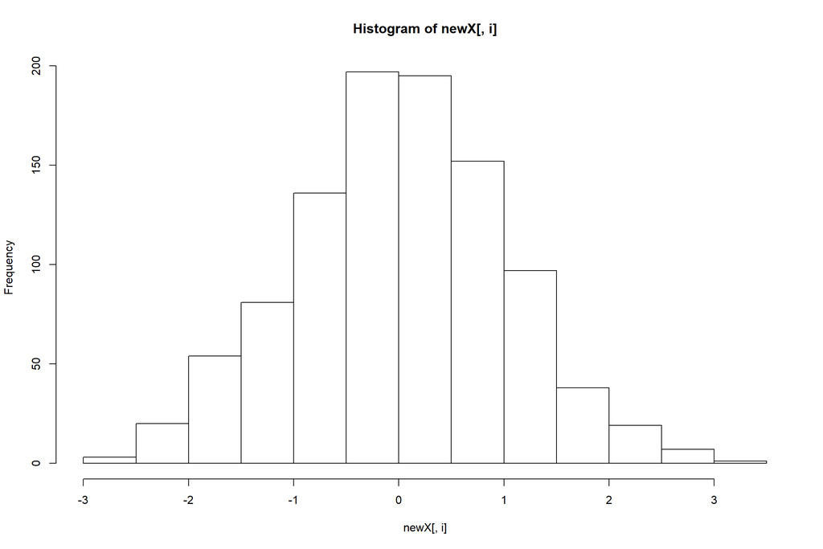

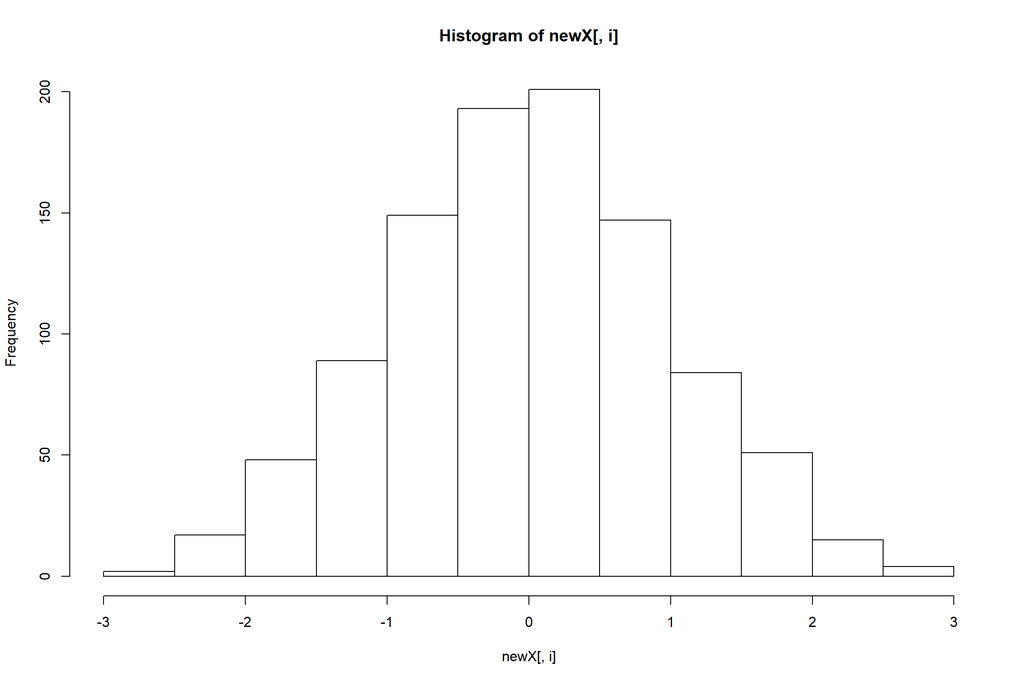

```
## [[1]]
## $breaks
##  [1] -3.5 -3.0 -2.5 -2.0 -1.5 -1.0 -0.5  0.0  0.5  1.0  1.5  2.0  2.5  3.0
## [15]  3.5  4.0  4.5
##
## $counts
##  [1]   2   5  16  44 101 148 196 193 140  89  41  21   3   0   0   1
##
## $density
##  [1] 0.004 0.010 0.032 0.088 0.202 0.296 0.392 0.386 0.280 0.178 0.082
## [12] 0.042 0.006 0.000 0.000 0.002
##
## $mids
##  [1] -3.25 -2.75 -2.25 -1.75 -1.25 -0.75 -0.25  0.25  0.75  1.25  1.75
## [12]  2.25  2.75  3.25  3.75  4.25
##
## $xname
## [1] "newX[, i]"
##
## $equidist
## [1] TRUE
##
## attr(,"class")
## [1] "histogram"
##
## [[2]]
## $breaks
##  [1] -3.0 -2.5 -2.0 -1.5 -1.0 -0.5  0.0  0.5  1.0  1.5  2.0  2.5  3.0  3.5
##
## $counts
##  [1]   3  20  54  81 136 197 195 152  97  38  19   7   1
##
## $density
##  [1] 0.006 0.040 0.108 0.162 0.272 0.394 0.390 0.304 0.194 0.076 0.038
## [12] 0.014 0.002
##
## $mids
##  [1] -2.75 -2.25 -1.75 -1.25 -0.75 -0.25  0.25  0.75  1.25  1.75  2.25
## [12]  2.75  3.25
##
```

[output cut: 17 more lines]

```
##  [1] 0.004 0.034 0.096 0.178 0.298 0.386 0.402 0.294 0.168 0.102 0.030
## [12] 0.008
##
## $mids
##  [1] -2.75 -2.25 -1.75 -1.25 -0.75 -0.25  0.25  0.75  1.25  1.75  2.25
## [12]  2.75
##
## $xname
## [1] "newX[, i]"
##
## $equidist
## [1] TRUE
##
## attr(,"class")
## [1] "histogram"
```

```r
#d
z<-matrix(rnorm(3000),(nrows=3))
apply(z,MARGIN=1,hist)
```

5. Write a function:
- input a vector $v$ and a value $n$
- out the original vector with its missing data in $v$ being replaced by $n$.

$v$ could be a numeric or characrer vector and $n$ could be a number or a string. If there is no missing value, return $v$ and the message `There is no missing value.`

```r
five = function(v,n) {
  if (anyNA(v)) {
    for (i in 1:length(v)) {
      if (is.na(v[i])) {
        v[i] = n
      }
      else {
        v[i] = v[i]
      }
    }
    return (v)
  }
  else {
    print ("There is no missing value.")
    return (v)
  }
}

five(c('two',3,'four',5),"five")
```

```
## [1] "There is no missing value."
```

```
## [1] "two"  "3"    "four" "5"
```

6. Write a function:
- input a numeric vector
- output the original vector with its missing data being replaced by the mean of the vector. If there is no missing value, return the original vector with the message `There is no missing value.`

```r
six = function (v) {
  if (anyNA(v)) {
    for (i in 1:length(v)) {
      if (is.na(v[i])) {
      v[i] = mean(v,na.rm=TRUE)
      }
      else {
      v[i] = v[i]
      }
    }
    return (v)
  }
  else {
    print ("There is no missing value.")
    return (v)
  }
}

six(c(1,2,3,4,5,6))
```

```
## [1] "There is no missing value."
```

```
## [1] 1 2 3 4 5 6
```

7. Write a function:
- input a character/factor vector
- output a vector with its missing data being replaced by the mode of the vector. If there is no missing value, return the original vector with the message `There is no missing value.`

```r
#function to calculate mode in a vector
Mode = function(x){
    ta = table(x)
    tam = max(ta)
    if (all(ta == tam))
         mod = NA
    else
         if(is.numeric(x))
    mod = as.numeric(names(ta)[ta == tam])
    else
         mod = names(ta)[ta == tam]
    return(mod)
}
#actual function
seven = function(v) {
  if (anyNA(v)) {
    for (i in 1:length(v)) {
      if (is.na(v[i])) {
      v[i]= Mode(v)
      }
      else {
      v[i] = v[i]
      }
    }
    return (v)
  }
  else {
    print ("There is no missing value.")
    return (v)
  }
}
seven(c('three','three','three','four','five','five',NA,NA))
```

```
## [1] "three" "three" "three" "four"  "five"  "five"  "three" "three"
```

8. Write a function:
- input a data frame
- output the data frame with numeric missing values being replaced by the corresponding column mean and categorical missing values being replaced by the corresponding column mode.

Check to confirm that the function woks with the `titanic` dataset.

```r
eight = function(d) {
  for (i in 1:ncol(d)) {
    if (is.numeric(d[[i]])) {
      d[[i]] = six(d[[i]])
    }
    if (is.character(d[[i]])) {
      d[[i]] = seven(d[[i]])
    }
  }
  return (d)
}

eight(titanic)
```

```
## [1] "There is no missing value."
## [1] "There is no missing value."
## [1] "There is no missing value."
## [1] "There is no missing value."
## [1] "There is no missing value."
## [1] "There is no missing value."
## [1] "There is no missing value."
## [1] "There is no missing value."
## [1] "There is no missing value."
```

```
## # A tibble: 891 x 12
##    PassengerId Survived Pclass Name  Sex     Age SibSp Parch Ticket  Fare
##          <dbl> <chr>    <chr>  <chr> <chr> <dbl> <dbl> <dbl> <chr>  <dbl>
##  1           1 0        3      Brau~ male   22       1     0 A/5 2~  7.25
##  2           2 1        1      Cumi~ fema~  38       1     0 PC 17~ 71.3
##  3           3 1        3      Heik~ fema~  26       0     0 STON/~  7.92
##  4           4 1        1      Futr~ fema~  35       1     0 113803 53.1
##  5           5 0        3      Alle~ male   35       0     0 373450  8.05
##  6           6 0        3      Mora~ male   29.7     0     0 330877  8.46
##  7           7 0        1      McCa~ male   54       0     0 17463  51.9
##  8           8 0        3      Pals~ male    2       3     1 349909 21.1
##  9           9 1        3      John~ fema~  27       0     2 347742 11.1
## 10          10 1        2      Nass~ fema~  14       1     0 237736 30.1
## # ... with 881 more rows, and 2 more variables: Cabin <chr>,
## #   Embarked <chr>
```

9. Write a function that
- input two categorical variables
- output the a bar chart of one variable color filled by the other variable.

Check your function with two categorical variables in the titanic data

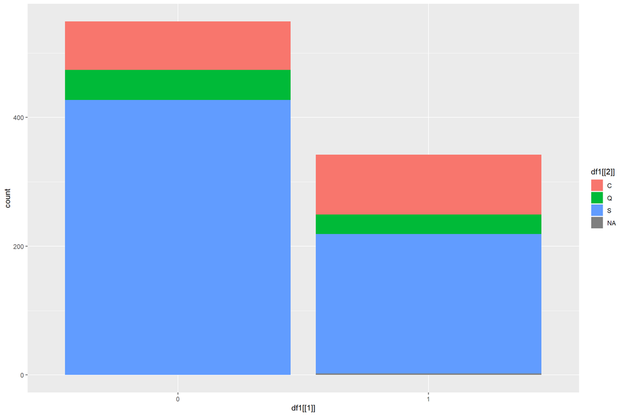

```r
nine = function(a,b) {
  df1 = as_tibble(cbind(a,b))
  ggplot(df1, aes( x = df1[[1]], fill =df1[[2]]))+
           geom_bar()

}

nine(titanic$Survived,titanic$Embarked)
```

10. Write a function that
- input an data frame
- output all the possible bar charts of a categorical variable filled by another categorical variables where both of the two variables must have the number of categories less than 4.

Check your function on the titanic data

```
## [1] "Survived" "Survived"
```

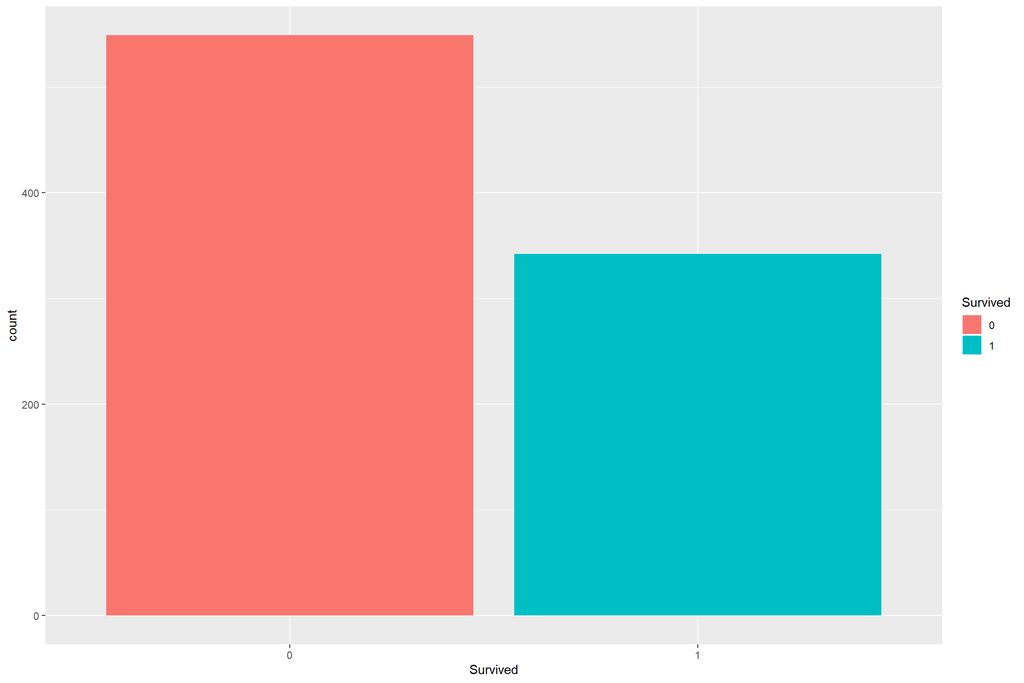

```
## [1] "Survived" "Pclass"
```

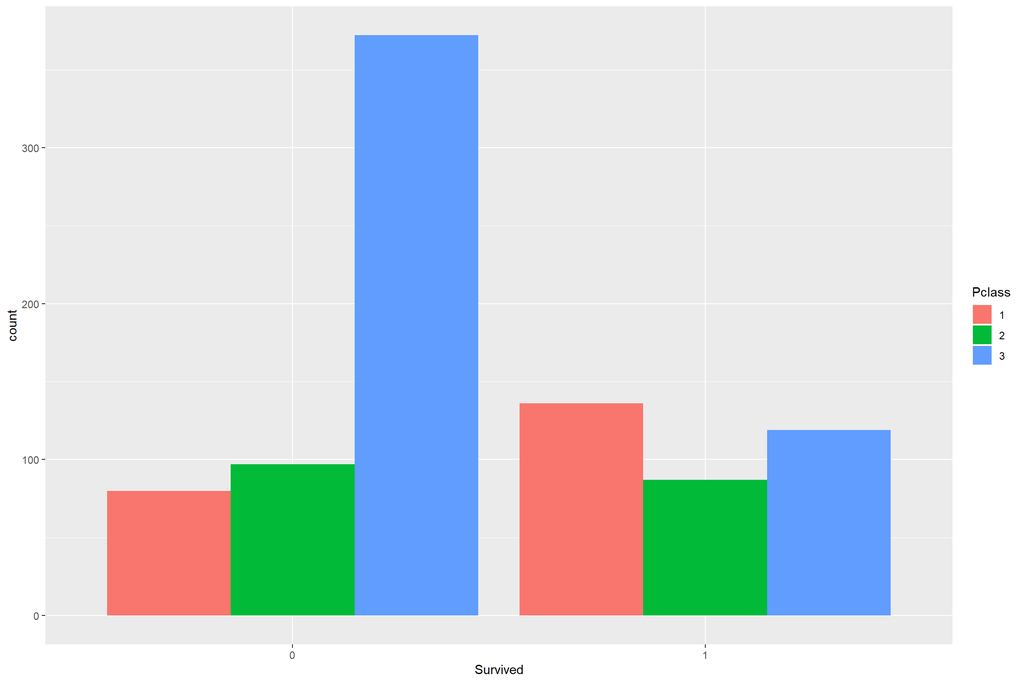

```
## [1] "Survived" "Sex"
```

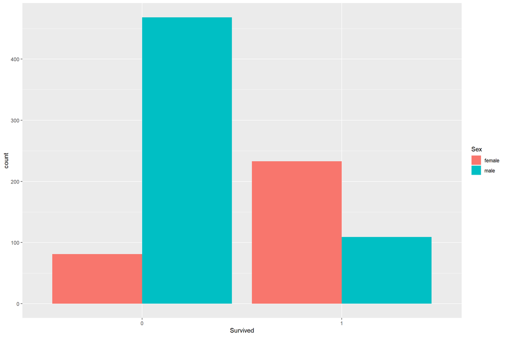

```
## [1] "Survived" "Embarked"
```

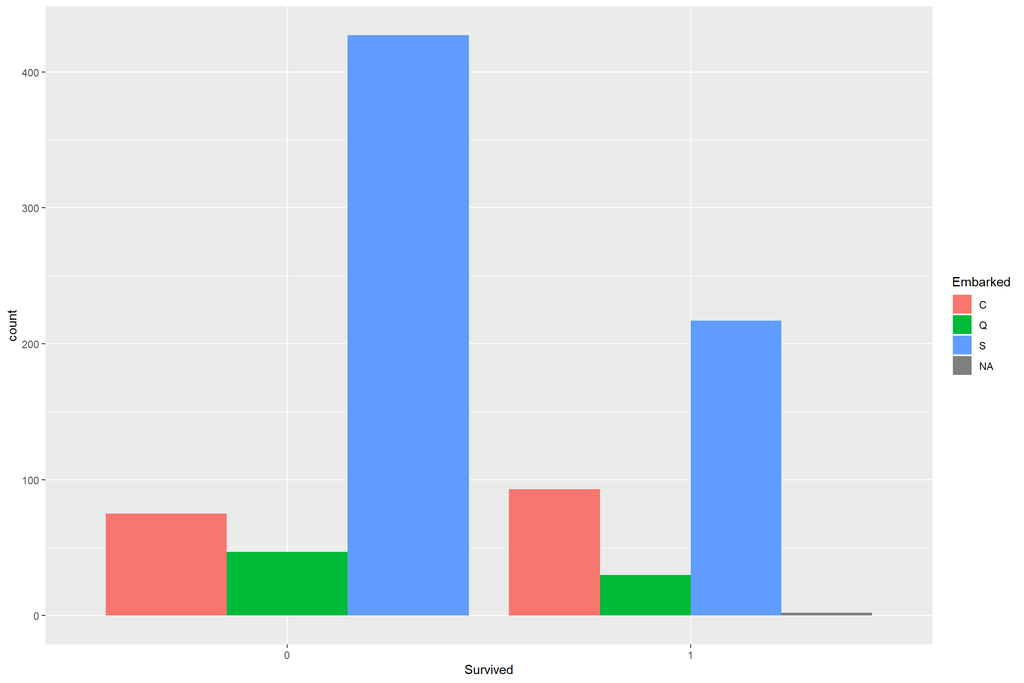

```
## [1] "Pclass"   "Survived"
```

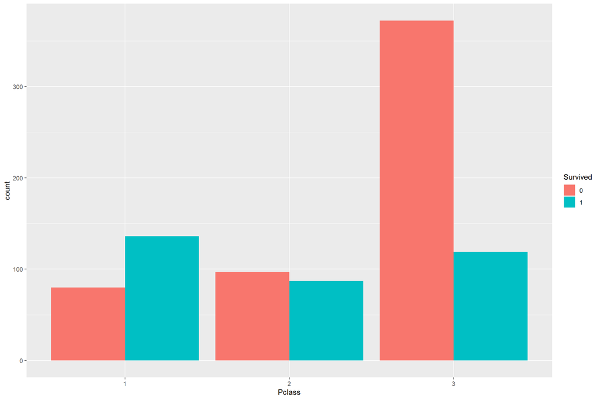

```
## [1] "Pclass" "Pclass"
```

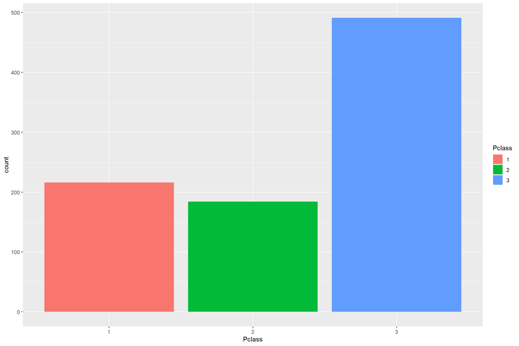

```
## [1] "Pclass" "Sex"
```

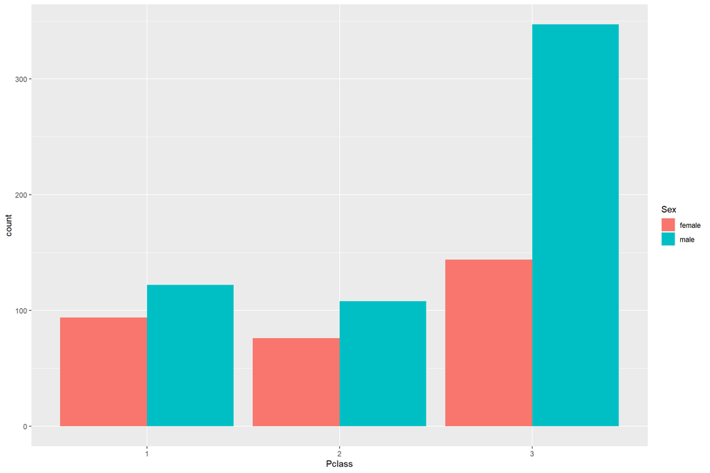

```
## [1] "Pclass"   "Embarked"
```

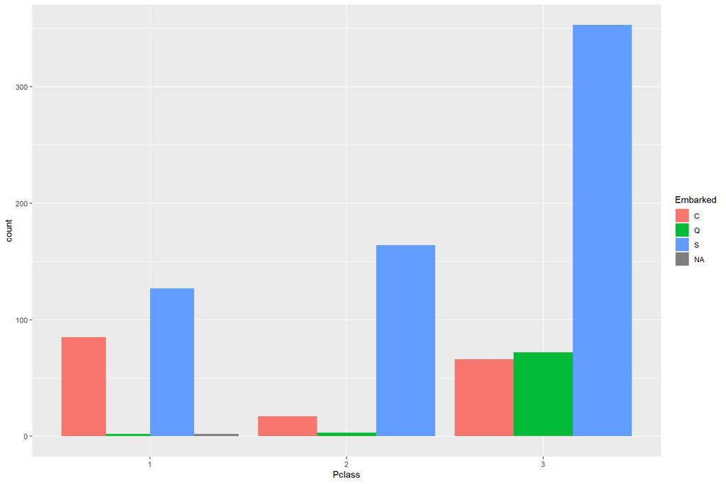

```
## [1] "Sex"      "Survived"
```

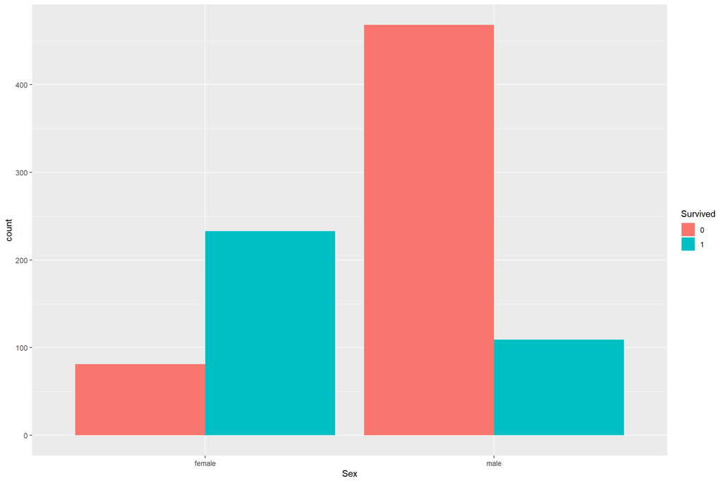

```
## [1] "Sex"    "Pclass"
```

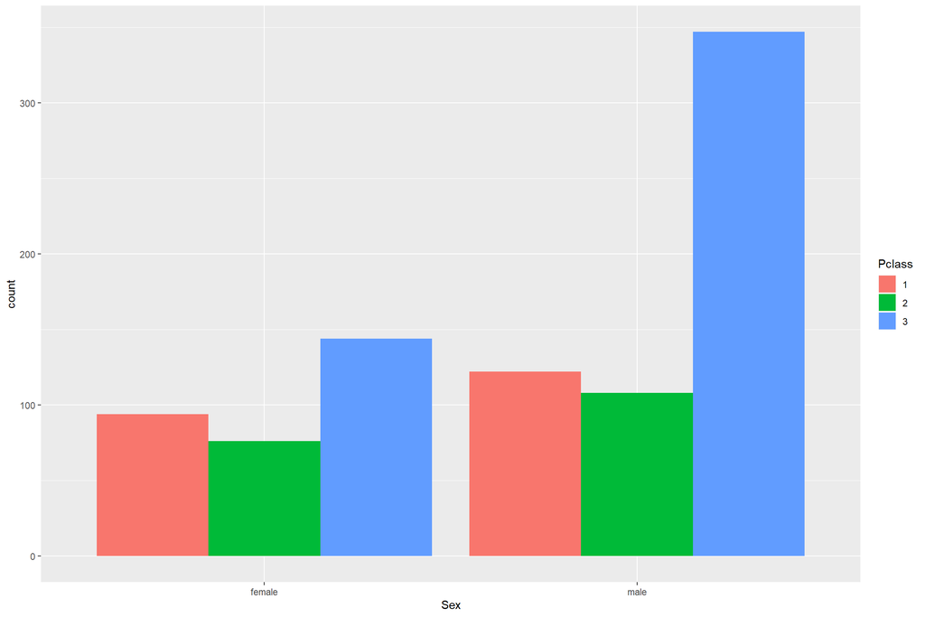

```
## [1] "Sex" "Sex"
```

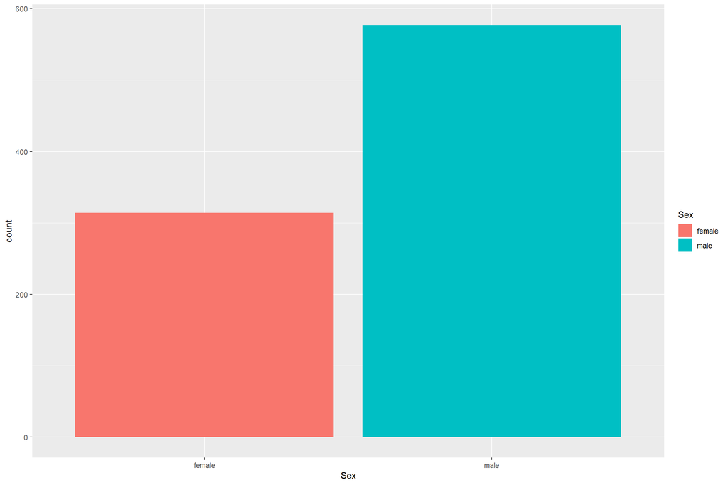

```
## [1] "Sex"      "Embarked"
```

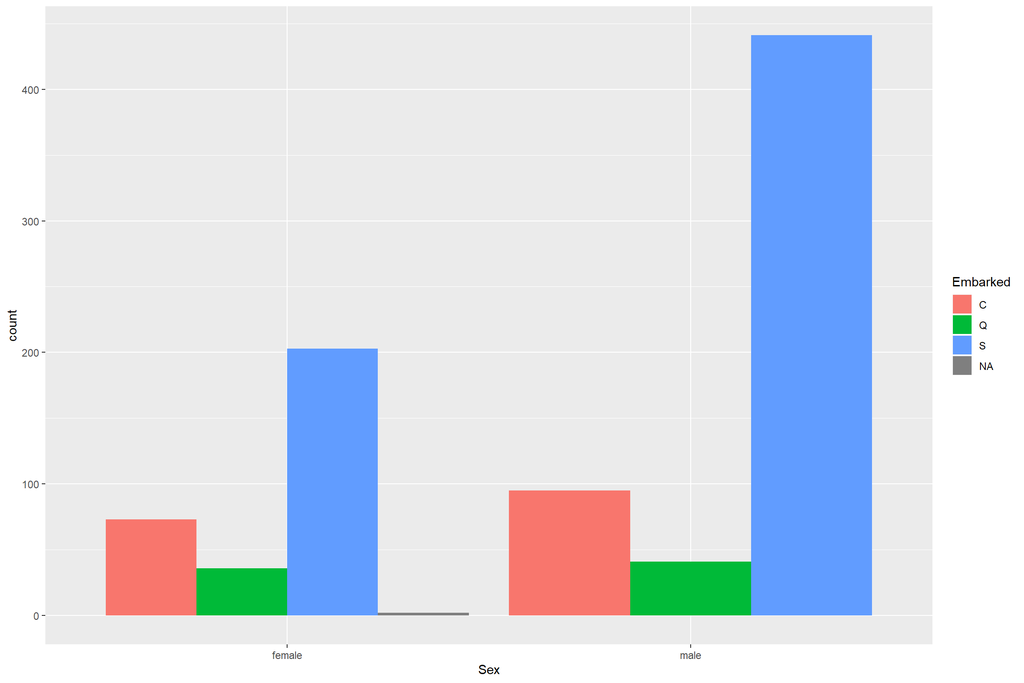

```
## [1] "Embarked" "Survived"
```

[4 more figures not shown]

```r
ten = function(d) {
  df1 = d[, sapply(d, function(col) length(unique(col))) <= 4]
  for (i in 1:(ncol(df1))) {
    for (j in 1:ncol(df1)) {
      print(names(df1)[c(i,j)])
      print(ggplot(df1,aes(x = df1[[i]], fill = df1[[j]])) + geom_bar(position = 'dodge')+labs(x = names(df1)[[i]], fill = names(df1)[[j]]))
    }
  }
}

ten(titanic)
```

11. Write a function for a quick visualization that input a (cleaned) data and a number $k$ and output the follows
- If $k=1$, output all the possible bar charts of a categorical variable filled by another categorical variables where both of the two variables must have the number of categories less than 4.
- If $k=2$, output all the possible density curve (using `geom_density`), i.e. density curves of all numeric variables
- If $k=3$, all possible density curves of all numeric variables coloring by a categorical variable with the number of categories less than 4.

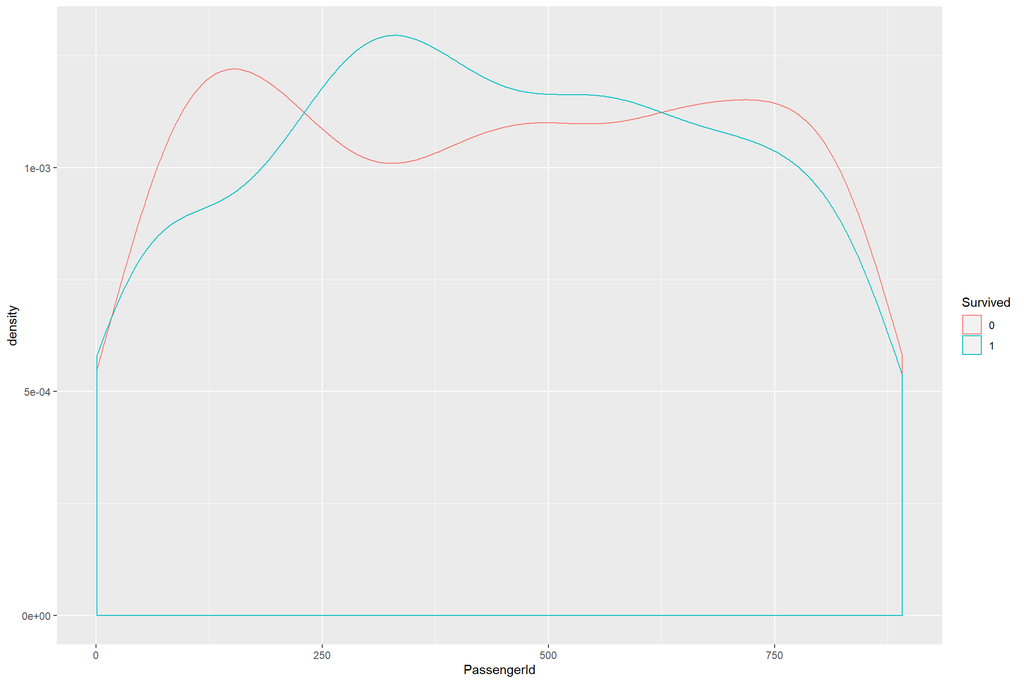

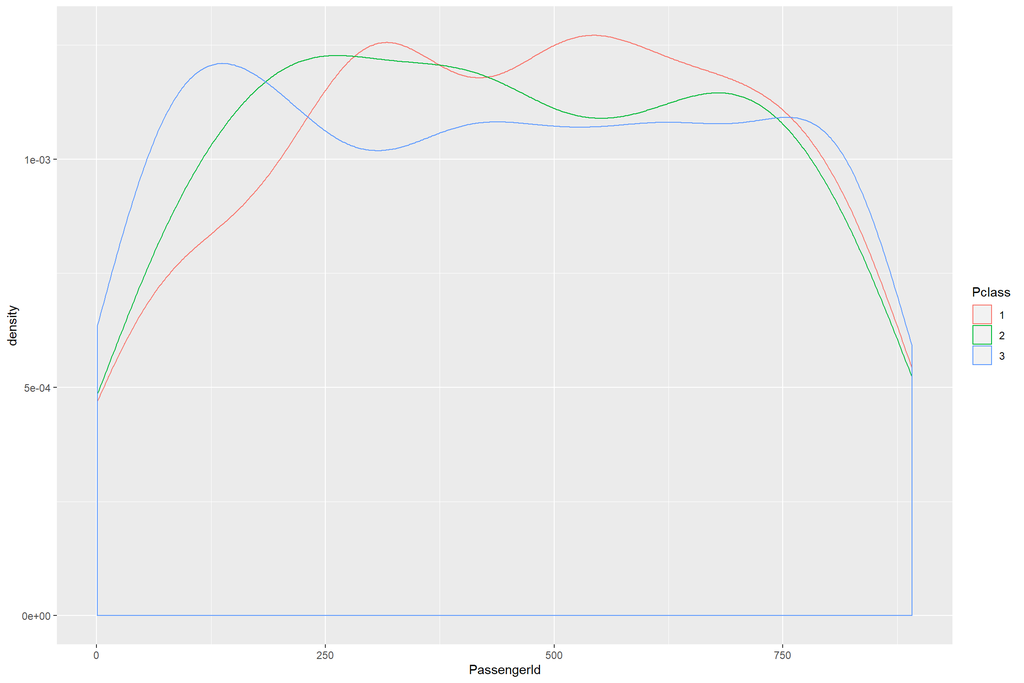

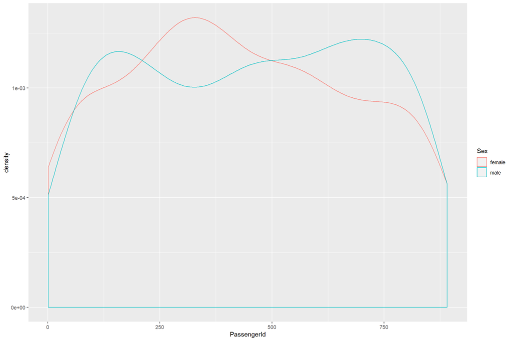

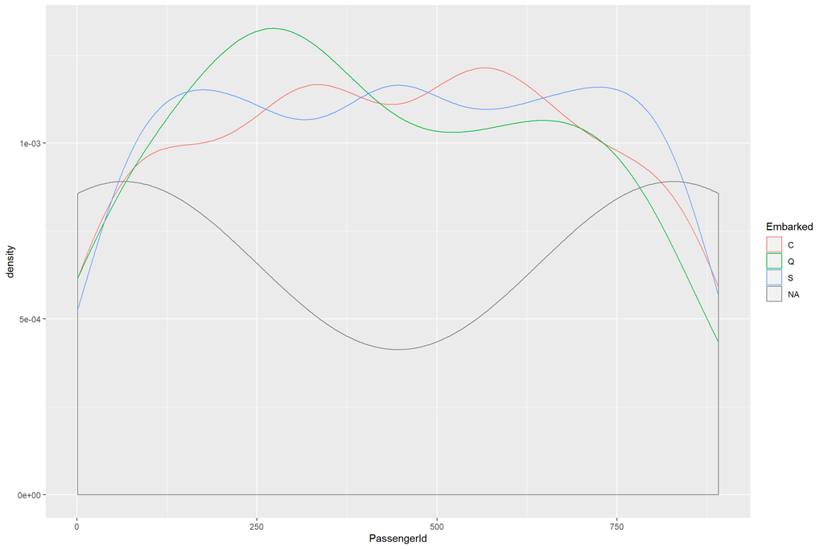

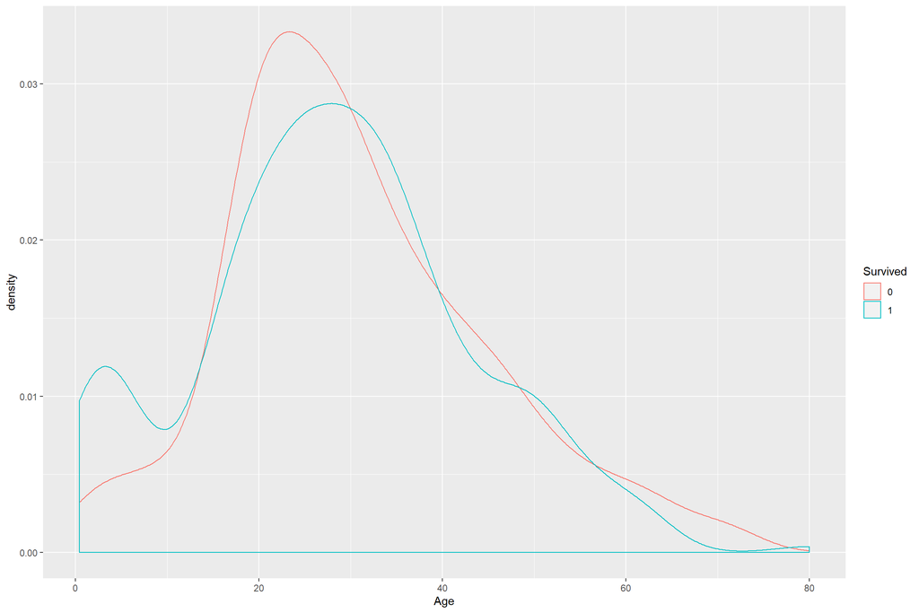

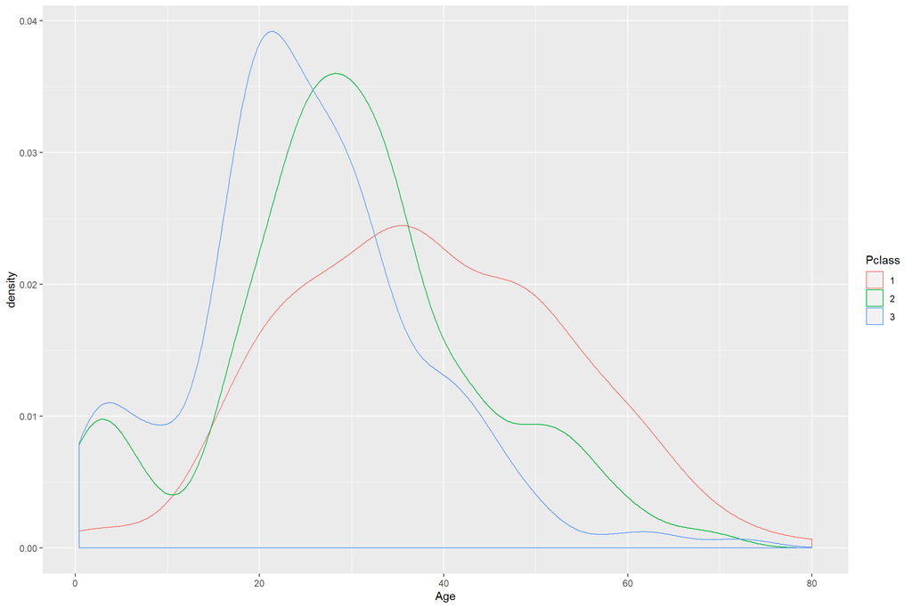

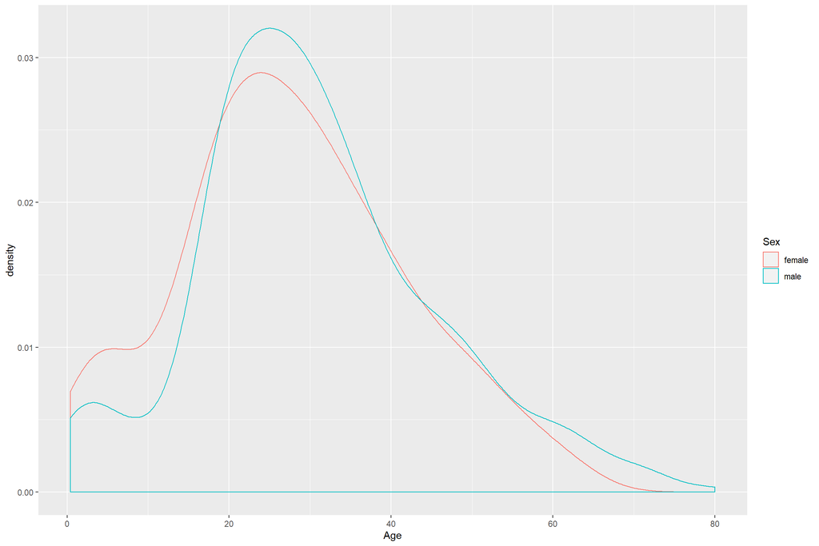

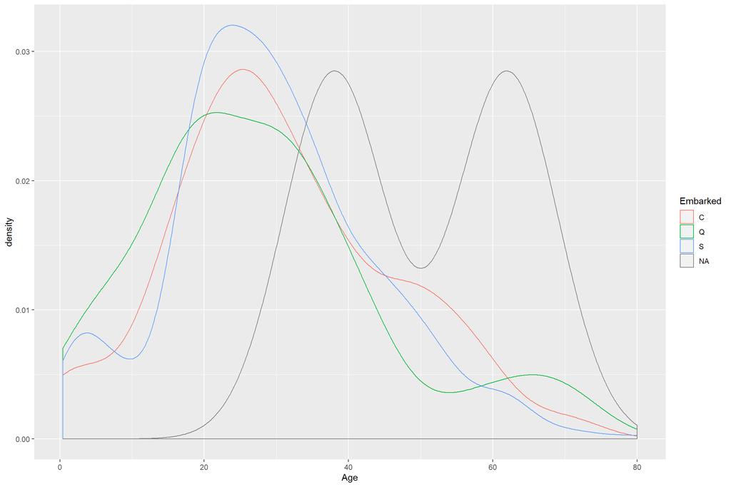

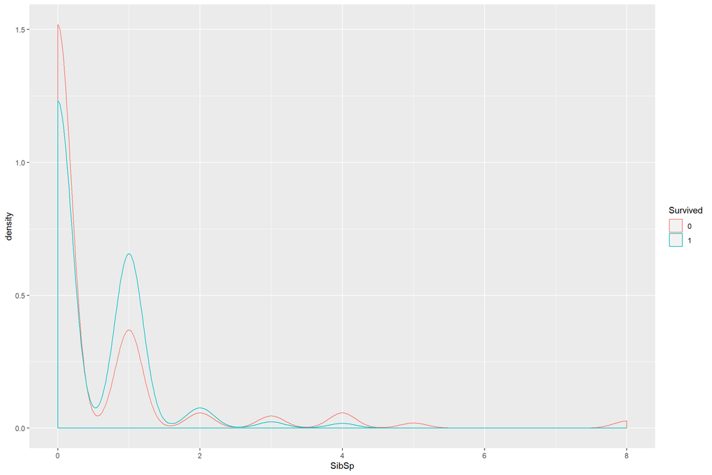

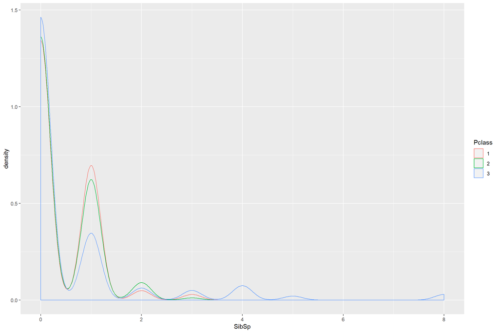

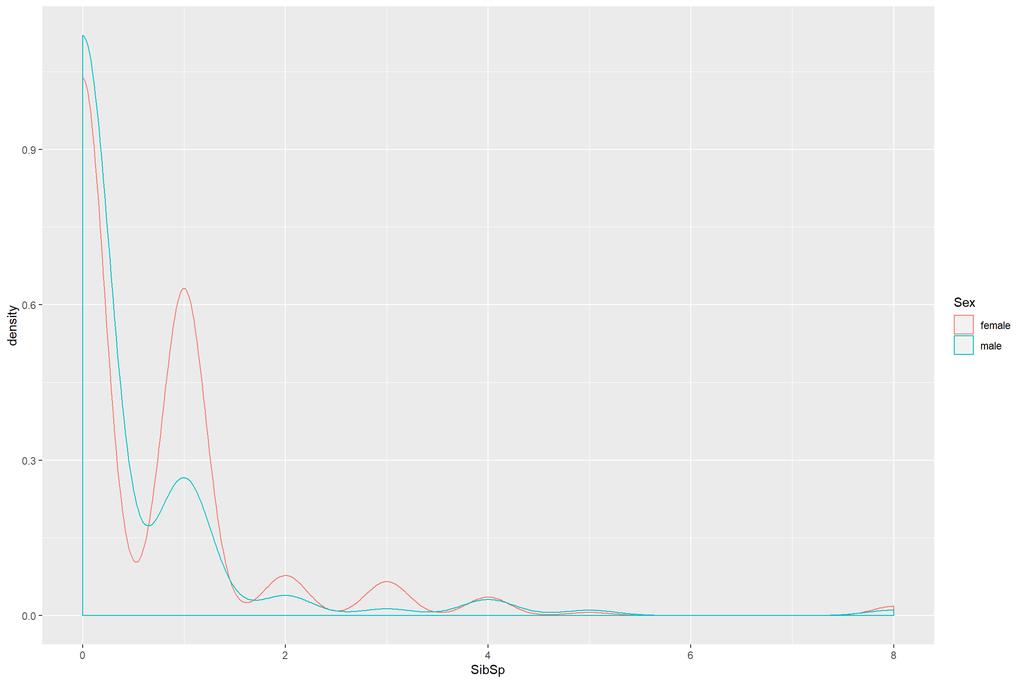

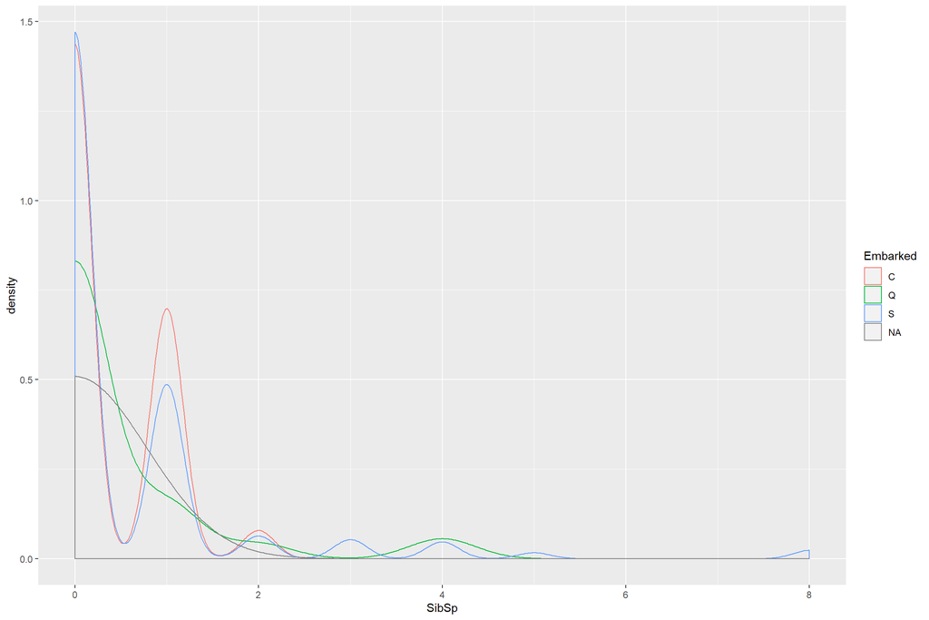

[8 more figures not shown]

```r
eleven = function(d,k) {
  if (k==1) {
    ten(d)
  }
  if (k==2) {
    df1 = d[, sapply(d, function(col) is.numeric(col))]
    for (i in 1: ncol(df1)) {
      print (names(df1)[i])
      print (ggplot(df1, aes(x = df1[[i]]))+geom_density()+labs(x = names(df1)[[i]]))
    }
  }
  if (k==3) {
    df1 = d[, sapply(d, function(col) is.numeric(col))]
    df2 = d[, sapply(d, function(col) length(unique(col))) <= 4]
    for (i in 1: ncol(df1)) {
      for (j in 1:ncol(df2)) {
        print(ggplot(data=df1,aes(x = df1[[i]]))+geom_density(data = df2, aes(col = df2[[j]]))+labs(x = names(df1)[[i]], col = names(df2)[[j]]))
  }
}
  }
}

eleven(titanic,3)
```